# A3: SPL Library Checkouts

### Introduction

I will be doing trends of checkout rates of different psychology medias from 2017 to 2023, trends of checkout rates of four popular book to movies/tv shows checkout rates, and my last graph will be the total checkout rate of the most popular author on tiktok, Colleen Hoover. I decided to do psychology because I wanted to see if their was any increase checkouts of self help books during the pandemic because there was an increase of mental instability during that time. I wanted to see if people had turned to books if they couldn’t connect through therapy. For my second chart, I did four series and their checkout rates over time. I read *Harry Potter*, *A Song of Ice and Fire* and the second book of *Twilight* but I had only seen the movie version of *Lord of the Rings*. These four are still quite popular today and have amassed a cult following. Therefore I wanted to see if active news within the fandoms have affected the checkouts. In Chart 3, I looked at the most popular books released by the most popular author on tiktok, Colleen Hoover. I actually hate Hoover’s books but her books are always on social media so I thought what’s the most popular in her collection?

### The Dataset

This dataset comes from Seattle Open Data program that is run by the City of Seattle. The Seattle Open Data is the one who provided the data to the public, but it is the Seattle Public Library who collected the data. They don’t list the book’s ISBN numbers on their data, although it is still a category. The City of Seattle provides this data with the ideology of keeping the people transparent about what happens in Seattle. The dataset is updated monthly, usually around the 6th of each month. They started in 2005, and collect data on both physical media and digital. The physical media can be things like books and video discs, while digital could be ebooks and audiobooks. I think the limitations of this data is that the labeling of subjects is a bit inconsistent.

### Psychology Book Checkout Rates Over Time

In this chart I wanted to see if people were checking these items out in digital format but surprisingly, no psychology book was checked out in ebook format. There was a big spike in checkouts in December of 2017. And looking at the dataset it was actually one specific book that was written by a neurologist before his death. As expected there was a low checkout rate during the early pandemic and then a slight surge around 2021 when places started to open up again.

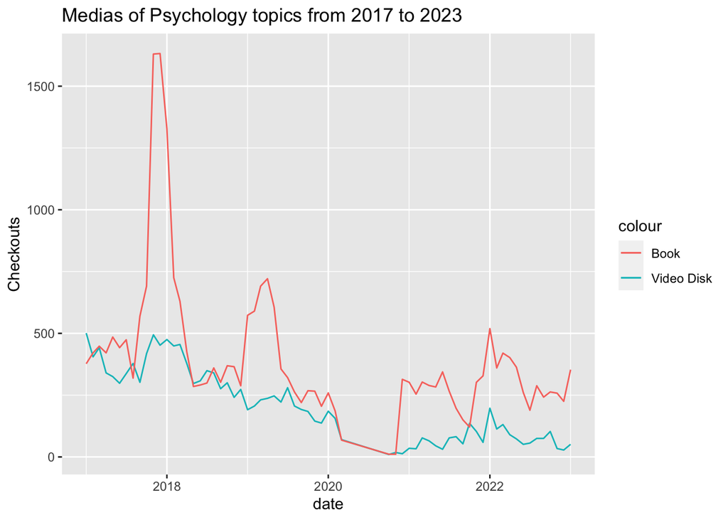

### Trends of Four Popular Books to Visual Media Adaptations

For my second chart I analyzed four popular book to visual media series. There was a surge of *Harry Potter* checkouts that occurred with it’s checkout for the month being 3681. I am not too sure why that happened it was either something to do with the release of *Fantastic Beast* or maybe *The Cursed Child.* There was also a spike for the *Lord of the Rings*, at December of 2020 where it jumped from 91 to 254. To be honest I thought it might have been the reveal of the new tv show but that wasn’t until late 2022.

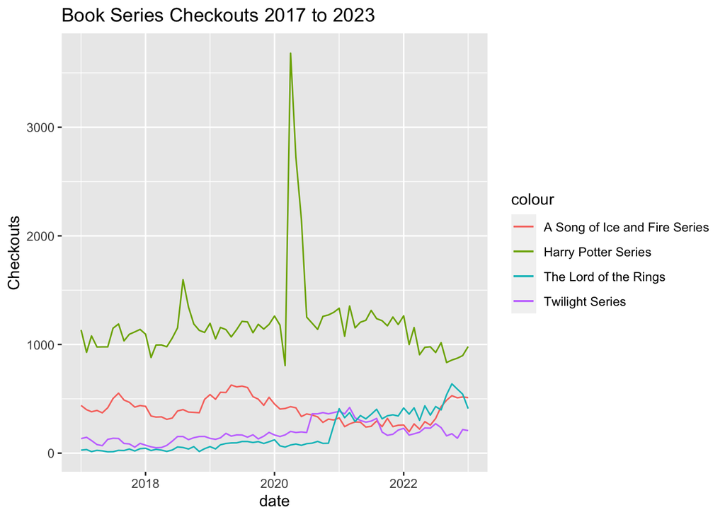

### The Rise of Colleen Hoover

In Chart 3, *It Ends with Us* was the most popular with being 5803 checkouts and its sequel, *It Starts with Us* released last year, had 1171 checkouts. None of Hoover’s other books can compete with the success of *It Ends with Us*.

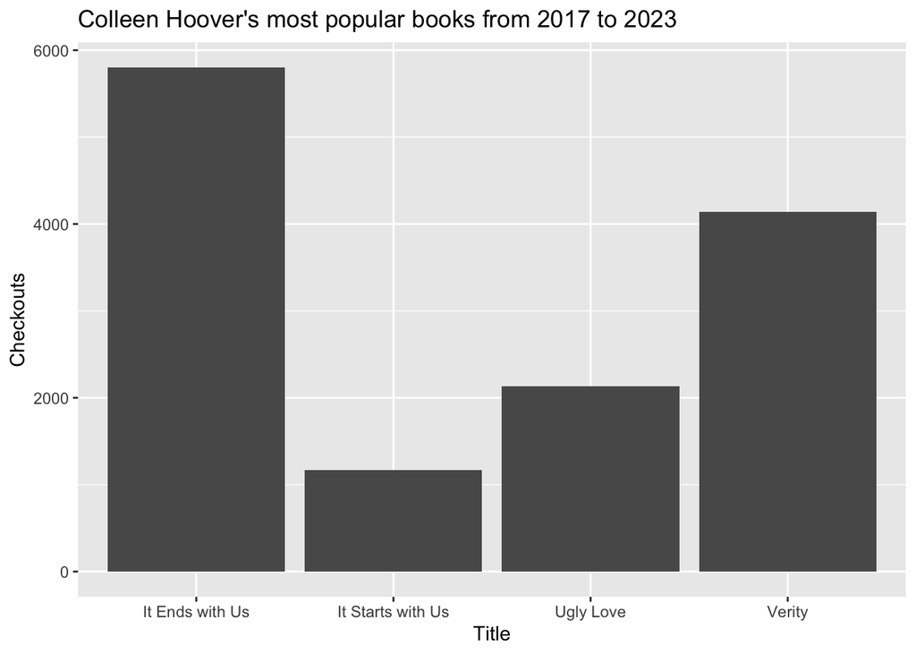